# Recommending University Courses

Michael Dombrowski

# Background

The goal of this project is to utilize data that I have collected from the schedule generator that I operate in order to recommend courses to students based on two or more courses that they have shown an interest in. To accomplish this, I will be creating at least two models; one for predicting the field of study and another for the course number. To know what a good recommendation is, I will be randomly removing one course from all student lookups and moving the true answer to separate columns to be predicted later.

# Data Preparation

## Reading In Data

```r
library(readr)
library(knitr)
library(dplyr)
library(ggplot2)
library(viridis)
library(stringi)
library(jsonlite)
library(keras)
library(xgboost)
theme_set(theme_minimal())

raw_lookups <- fromJSON("lookups.json", flatten=TRUE, simplifyDataFrame = TRUE)
# Only keep lookups with more than 2 course (since we're going to removing 1 randomly)
# Only keep certain columns
raw_lookups <- raw_lookups[raw_lookups$numCourses > 2, names(raw_lookups) %in% c("id", "timestamp", "lookup", "userID", "numCourses")]
numData <- nrow(raw_lookups)
```

Before I get started with the statistical learning work, let’s have a look at the data that I’m working with.

```r
kable(raw_lookups[1,])
```

| id | timestamp | lookup | userID | numCourses |
| --- | --- | --- | --- | --- |
| 1 | 1459348564 | {“allCourses”:[{“CourseNum”:320,“FOS”:“MKT”,“Title”:“Principles of Marketing”},{“CourseNum”:301,“FOS”:“CMSC”,“Title”:“Computer Organization”},{“CourseNum”:360,“FOS”:“FIN”,“Title”:“Principles of Financ… | 261388311.1459201813 | 4 |

My main source of data is the lookup column which contains JSON encoded data, and within that the most important part is the “allCourses” section.

```r
jsonlite::prettify(raw_lookups$lookup[1])
```

```
## {
##     "allCourses": [
##         {
##             "CourseNum": 320,
##             "FOS": "MKT",
##             "Title": "Principles of Marketing"
##         },
##         {
##             "CourseNum": 301,
##             "FOS": "CMSC",
##             "Title": "Computer Organization"
##         },
##         {
##             "CourseNum": 360,
##             "FOS": "FIN",
##             "Title": "Principles of Financial Management"
##         },
##         {
##             "CourseNum": 334,
##             "FOS": "CMSC",
##             "Title": "Computer Security"
##         }
##     ],
##     "timePref": false,
##     "fullClasses": true,
##     "preregistered": [
##         ""
##     ],
##     "startTime": "8:00 AM",
##     "endTime": "10:00 PM",
##     "unwantedTimes": [
##
##     ],
##     "timestamp": 1459348564
## }
##
```

## Data Splitting

```r
percent_training <- 70
```

I will start off by splitting the data into training and validation sets with 70% going into training. The split will be completely random, so it is possible that a single user will be in the validation and training sets. I chose not to split based on the individual because That would limit the amount of data I have too much.

```r
set.seed(1)
train_ind <- sample(seq_len(numData), size = floor((percent_training/100) * numData))
raw_lookups$train_id <- "valid"
raw_lookups$train_id[train_ind] <- "train"
```

## Remove A Course To Predict Later

Now I am going to remove a single course from every lookup and put it into two new columns, one for the field of study (ex. CMSC) and one for the course number (ex. 101). While doing this I will also cleanup the data so that it is easier to parse later on.

```r
library(stringr)
fields_of_study <- c()

for(i in seq(1, numData)){
    l <- raw_lookups$lookup[i]
    l <- gsub("[\r\n\t]", "", l) # Some data has newlines and tabs wich cannot be parsed by this JSON parser
    l <- fromJSON(l)

    l$allCourses <- Filter(length, l$allCourses) # Remove any empty JSON arrays/objects since they don't get turned into dataframes, but lists
    if(!is.data.frame(l$allCourses)){
        # Hack around jsonlite not making a dataframe by first converting to JSON, then back into a dataframe
        l$allCourses <- fromJSON(toJSON(l$allCourses), flatten=TRUE, simplifyDataFrame = TRUE)
    }

    for(j in seq(1, nrow(l$allCourses))){
        field <- l$allCourses$FOS[[j]]
        if(!(field %in% fields_of_study)){
            fields_of_study <- c(fields_of_study, field)
        }
    }

    # Randomly remove 1 course and re-save the JSON
    cnum <- sample(seq_len(nrow(l$allCourses)), size = 1)
    raw_lookups$missing_fos[i] <- l$allCourses$FOS[[cnum]]
    raw_lookups$missing_crse[i] <- as.numeric(str_extract(l$allCourses$CourseNum[[cnum]], "\\d+"))
    l$allCourses <- l$allCourses[-cnum,]
    raw_lookups$new_lookup[i] <- toJSON(l)
}

raw_lookups$missing_fos_num <- match(raw_lookups$missing_fos, fields_of_study)
```

# Modelling

## Creation of Predictive Variables

Below I create a column for every field of study and populate each with zeroes. I then go through the whole dataset and fill in the number of courses in each category, excluding the removed course that will be predicted. I also create columns for minimum, maximum, and average course numbers so that I can predict the missing course number.

```r
for(i in seq(1, length(fields_of_study))){
    field <- fields_of_study[i]
    # Make column for field and fill with 0 if it doesn't already exist
    if(!(field %in% colnames(raw_lookups))){
        raw_lookups[[field]] <- 0
    }
}
raw_lookups$min_crse_num <- 0
raw_lookups$max_crse_num <- 0
raw_lookups$avg_crse_num <- 0

# Process each lookup and fill in the columns created above with the correct numbers
for(i in seq(1, numData)){
    l <- raw_lookups$new_lookup[i]
    l <- fromJSON(l, flatten = TRUE)

    for(j in seq(1, nrow(l$allCourses))){
        field <- l$allCourses$FOS[[j]]
        raw_lookups[i, field] <- raw_lookups[i, field] + 1
    }

    # Get the number of courses in the lookup
    raw_lookups$numCourses[i] <- nrow(l$allCourses)
    # Get course number string as a number
    courseNumber <- as.numeric(str_extract(l$allCourses$CourseNum, "\\d+"))
    raw_lookups$min_crse_num[i] <- min(courseNumber)
    raw_lookups$max_crse_num[i] <- max(courseNumber)
    raw_lookups$avg_crse_num[i] <- mean(courseNumber)
}
```

Now I will start trying to make models and predict the missing field of study and course number.

My first model will be a multinomial linear model in order to predict the field of study.

```r
library(nnet)

model <- multinom(reformulate(termlabels = c(fields_of_study, "numCourses"), response = "missing_fos"), data = raw_lookups, subset = train_id == "train", MaxNWts = 5000)
raw_lookups$fos_pred_multinom <- predict(model, newdata=raw_lookups, type="class")
multinom_acc <- tapply(raw_lookups$fos_pred_multinom == raw_lookups$missing_fos, raw_lookups$train_id, mean)
multinom_acc
```

```
##     train     valid
## 0.2598679 0.2003006
```

For such a simplistic model, it has a moderate accuracy of around 20% on the validation set. However, there are very likely many non-linearities that this model cannot possibly capture. Therefore, I will implement my next models using XGBoost and Keras for gradient boosted trees and neural networks respectively.

```r
X <- model.matrix(~ . - 1, data = raw_lookups[,colnames(raw_lookups) %in% c(fields_of_study, "numCourses")])
y <- raw_lookups$missing_fos_num-1

X_train <- X[raw_lookups$train_id == "train",]
y_train <- y[raw_lookups$train_id == "train"]
X_valid <- X[raw_lookups$train_id == "valid",]
y_valid <- y[raw_lookups$train_id == "valid"]

data_train <- xgb.DMatrix(data = X_train, label = y_train)
data_valid <- xgb.DMatrix(data = X_valid, label = y_valid)
watchlist <- list(train=data_train, valid=data_valid)

model <- xgb.train(data = data_train,
                 max_depth = 8, eta = 0.05, nthread = 8,
                 nrounds = 1000, objective = "multi:softmax",
                 num_class = length(fields_of_study),
                 watchlist = watchlist,
                 print_every_n = 100)
raw_lookups$fos_pred_xgb <- fields_of_study[predict(model, newdata = X)+1]
xgboost_fos_acc <- tapply(raw_lookups$fos_pred_xgb == raw_lookups$missing_fos, raw_lookups$train_id, mean)
xgboost_fos_acc
```

```
##     train     valid
## 0.7343322 0.3964675
```

The above model approximately doubles the accuracy of the multinomial model, achieving 40% accuracy on the validation set. The XGBoost model is, however, overfitting the training data which means that it may need further tweaking to the parameters. Despite the overfitting it is still performing very well on the validation data, so the overfitting may not be an issue.

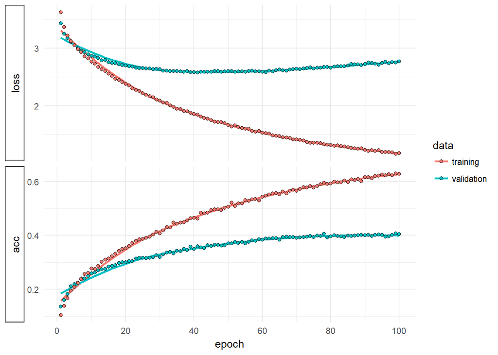

```r
X <- as.matrix(select(raw_lookups, numCourses, one_of(fields_of_study)))
X_train <- X[raw_lookups$train_id == "train",]
X_valid <- X[raw_lookups$train_id == "valid",]
y <- raw_lookups$missing_fos_num-1
y_train <- to_categorical(y[raw_lookups$train_id == "train"], num_classes = length(fields_of_study))
y_valid <- to_categorical(y[raw_lookups$train_id == "valid"], num_classes = length(fields_of_study))

dropoutRate <- .5
inputShape <- dim(X)[-1]
numUnits <- 1024
numHiddenLayers <- 2

model <- keras_model_sequential()
model %>%
    layer_dense(units = numUnits, kernel_initializer = "glorot_normal",
              input_shape = inputShape) %>%
    layer_activation(activation = "relu") %>%
    layer_dropout(rate = dropoutRate)

    for(i in seq(1, numHiddenLayers)){
        model %>%
            layer_dense(units = numUnits, kernel_initializer = "glorot_normal") %>%
            layer_activation(activation = "relu") %>%
            layer_dropout(rate = dropoutRate)
    }

    model %>%
        layer_dense(units = length(fields_of_study)) %>%
        layer_activation(activation = "softmax")

model %>% compile(loss = 'categorical_crossentropy',
                  optimizer = optimizer_adam(lr=0.0005),
                  metrics = c('accuracy'))

history <- model %>%
  fit(X_train, y_train, epochs = 100,
      validation_data = list(X_valid, y_valid), batch_size = 128)

plot(history)
```

```r
raw_lookups$fos_pred_nn <- fields_of_study[predict_classes(model, X)+1]
final_fos_acc_1 <- tapply(raw_lookups$fos_pred_nn == raw_lookups$missing_fos, raw_lookups$train_id, mean)
final_fos_acc_1
```

```
##     train     valid
## 0.7543097 0.4043593
```

In addition to the models shown above, I also experimented with RNN, LSTM, and CNN models, but never exceeded 33% with any of those techniques.

### Confusion Matrix

Before moving forward I will check the confusion matrix to see if there are any fields of study with obvious issues. Because the model is overfitting, I will view the confusion matrix for the validation data to see how it performs on real, unseen data.

```r
options(max.print = 100000)
options(knitr.kable.NA = '')
tab <- table(raw_lookups$missing_fos[raw_lookups$train_id == "valid"], raw_lookups$fos_pred_nn[raw_lookups$train_id == "valid"])
kable(local({tab[tab==0] <- "."; tab}), align = 'c')
```

|  | ACCT | AMST | ANTH | ARAB | ARTH | BIOL | BMB | BUAD | CHEM | CHIN | CJ | CLSC | CMSC | CRWR | DANC | ECON | EDUC | ENGL | ENVR | FIN | FMST | FREN | FYS | GEOG | GERM | GREK | HCS | HIST | IBUS | … |
| --- | --- | --- | --- | --- | --- | --- | --- | --- | --- | --- | --- | --- | --- | --- | --- | --- | --- | --- | --- | --- | --- | --- | --- | --- | --- | --- | --- | --- | --- | --- |
| ACCT | 67 | . | . | 2 | . | 6 | 1 | 7 | 2 | 1 | . | . | 6 | . | 1 | 10 | . | . | 1 | 1 | 1 | 1 | 10 | . | . | . | 1 | . | . | … |
| AMST | 1 | 1 | . | . | . | . | . | . | 1 | . | . | . | . | . | . | . | . | . | . | . | . | . | . | . | . | . | . | . | . | … |
| ANTH | 1 | . | 10 | . | . | 1 | . | . | 1 | . | . | . | . | . | . | 2 | . | 1 | . | . | . | . | 1 | . | . | . | . | . | . | … |
| ARAB | . | . | . | 2 | . | . | . | . | . | . | . | . | . | . | . | 2 | . | . | . | . | . | . | . | . | 1 | . | . | . | . | … |
| ARTH | . | . | . | . | 4 | 3 | . | 1 | . | . | . | . | 1 | . | . | 1 | . | . | . | 1 | . | . | 1 | . | . | . | . | . | . | … |
| BIOL | 3 | . | . | 1 | . | 35 | . | 1 | 11 | . | . | . | 3 | . | . | 8 | . | . | 1 | 2 | 1 | 2 | 10 | . | 1 | . | . | 3 | . | … |
| BMB | . | . | . | . | . | 1 | 5 | . | . | . | . | . | . | . | . | . | . | . | . | . | . | . | . | . | . | . | . | . | . | … |
| BUAD | 4 | . | . | . | . | . | . | 41 | 2 | 1 | . | . | 3 | . | 2 | 4 | . | 1 | . | 5 | . | . | 14 | . | . | . | . | 1 | . | … |
| CHEM | . | . | 1 | . | . | 5 | 1 | 1 | 57 | . | . | 2 | 4 | . | 1 | 5 | . | . | 1 | 2 | 1 | 1 | 8 | . | . | . | . | . | . | … |
| CHIN | . | . | . | . | . | . | . | . | . | 7 | . | . | . | . | . | 1 | . | . | . | . | . | . | 5 | . | . | . | . | . | . | … |
| CLSC | . | . | 1 | . | 1 | 1 | . | . | . | . | . | 3 | 2 | . | . | 1 | 1 | 2 | 1 | . | . | . | 2 | . | . | 1 | . | . | . | … |
| CMSC | 1 | . | . | . | . | 2 | . | 3 | 5 | . | . | . | 72 | . | . | 5 | . | . | 1 | . | . | . | 8 | . | 2 | . | . | 2 | . | … |
| DANC | . | . | . | . | . | . | . | . | 5 | . | . | . | 1 | . | 4 | . | . | . | . | . | . | . | 2 | . | . | . | . | . | . | … |
| ECON | 4 | . | 1 | . | . | 4 | . | 7 | 3 | . | . | 1 | 10 | . | . | 93 | . | 2 | 2 | 3 | . | 1 | 5 | . | . | . | 2 | 3 | . | … |
| EDUC | . | . | . | . | . | . | . | . | . | . | . | . | . | . | . | . | 5 | 1 | . | . | . | . | 2 | . | . | . | . | . | . | … |
| ENGL | 6 | 1 | . | . | . | 2 | . | 2 | 2 | . | . | . | 1 | 1 | . | 5 | . | 5 | 2 | 1 | 1 | 1 | 9 | . | . | . | . | 4 | . | … |
| ENVR | 1 | . | . | . | . | 3 | . | . | . | . | . | . | 3 | . | . | . | . | . | 9 | . | . | 1 | . | . | . | . | . | . | . | … |
| FIN | 4 | . | . | . | . | 1 | . | 5 | . | . | . | . | 1 | . | . | 3 | . | . | . | 18 | . | . | 2 | . | . | . | . | . | . | … |
| FMST | 1 | 1 | 1 | . | . | . | . | . | 1 | . | . | . | . | . | . | 1 | . | . | . | . | 2 | . | 1 | . | . | . | . | . | . | … |
| FREN | . | . | . | . | . | 1 | . | . | 2 | . | . | . | . | . | . | . | 1 | 1 | . | . | . | 9 | 4 | 1 | . | . | . | 1 | . | … |
| FYS | 2 | . | . | . | . | 4 | 1 | 5 | 9 | . | . | 1 | 2 | . | 1 | 6 | . | 1 | . | 1 | 1 | 1 | 189 | 1 | . | . | 2 | 2 | . | … |
| GEOG | . | . | 2 | . | . | 1 | . | . | 1 | . | . | . | . | . | . | 1 | . | . | 1 | . | . | . | . | 3 | . | . | 1 | . | . | … |
| GERM | 1 | . | 1 | 1 | . | . | . | 2 | . | . | . | . | . | . | . | 1 | . | . | . | . | 1 | . | 2 | . | 2 | . | . | . | . | … |
| GREK | . | . | . | . | . | . | . | . | . | 1 | . | . | . | . | . | . | . | . | . | . | . | . | . | . | 2 | . | . | . | . | … |
| HCS | . | . | . | . | . | . | . | 1 | 4 | . | . | . | . | . | . | 1 | . | 1 | . | . | . | . | 2 | . | . | . | 5 | . | . | … |
| HIST | . | . | 2 | 1 | 1 | 2 | 1 | . | 3 | . | . | . | . | . | . | 3 | . | . | . | 1 | . | . | 6 | . | . | 1 | . | 18 | . | … |
| IBUS | . | . | . | . | . | . | . | . | . | . | . | . | . | . | . | . | . | . | . | 1 | . | . | . | . | . | . | . | . | . | … |
| IDST | . | . | . | . | . | . | . | . | . | . | . | . | . | . | . | . | . | . | . | . | . | . | . | . | . | . | . | . | . | … |
| IS | 1 | . | . | . | . | . | . | . | . | . | . | . | . | . | . | 1 | . | . | . | . | . | . | . | . | . | . | . | . | . | … |
| ITAL | . | . | . | . | . | . | . | . | . | . | . | . | . | . | . | . | . | . | . | 1 | . | . | 1 | . | . | . | . | . | . | … |
| JAPN | . | . | . | . | . | . | . | . | . | . | . | . | 2 | . | . | . | . | 1 | . | . | . | . | 2 | . | . | . | . | . | . | … |
| JOUR | 1 | . | 2 | . | . | . | . | . | . | . | . | . | . | . | . | 2 | . | . | . | . | . | . | 1 | . | . | . | . | 2 | . | … |
| LAIS | . | . | . | 1 | 1 | 7 | . | 5 | 5 | . | . | 1 | 4 | . | . | 2 | . | 1 | 2 | . | . | 1 | 4 | . | . | . | . | . | . | … |
| LATN | . | . | . | . | . | . | . | . | . | . | . | . | 5 | . | . | . | . | 1 | . | . | . | 1 | 2 | . | . | . | . | 2 | . | … |
| LDST | 6 | . | 3 | 1 | . | 5 | . | 1 | 1 | . | . | 2 | 3 | . | . | 4 | 1 | 3 | . | . | . | . | 3 | . | . | . | . | 3 | . | … |
| LLC | . | . | 1 | . | . | . | . | . | . | . | . | . | 1 | . | . | 3 | . | . | . | . | . | . | 1 | . | . | . | . | . | . | … |
| MATH | 8 | . | 2 | . | . | 4 | . | 4 | 8 | . | . | . | 14 | . | . | 13 | . | 2 | 2 | 1 | . | 3 | 12 | . | 1 | . | 4 | 3 | . | … |
| MGMT | 4 | . | 1 | . | . | . | . | 7 | . | . | . | . | 2 | . | . | 3 | . | . | . | 9 | . | . | . | . | . | . | . | 1 | . | … |
| MKT | 2 | . | . | . | . | . | . | 2 | 2 | . | . | . | . | . | . | . | . | . | . | 6 | . | . | . | . | . | . | . | . | 1 | … |
| MSCL | . | . | . | . | . | . | . | . | . | . | 1 | . | . | . | . | . | . | . | . | . | . | . | . | . | . | . | . | . | . | … |
| MSEN | . | . | . | . | . | . | . | . | 1 | . | . | . | . | . | . | . | . | . | . | . | . | . | . | . | . | . | . | . | . | … |
| MUS | . | . | . | . | . | . | . | 1 | . | . | . | . | . | . | . | 3 | . | 1 | . | . | . | . | 1 | . | . | . | 1 | 1 | . | … |
| PHIL | . | . | . | . | . | 1 | . | 1 | 3 | . | . | . | . | . | . | 4 | . | 1 | 1 | . | . | . | 3 | . | . | . | 1 | . | . | … |
| PHYS | 1 | . | . | . | . | 3 | . | . | 3 | . | . | . | 1 | . | . | . | . | . | . | 1 | . | . | 6 | . | . | . | . | . | . | … |
| PLSC | 5 | . | . | . | . | 2 | . | . | 1 | . | . | . | . | . | . | 5 | . | . | 1 | 1 | . | 1 | 6 | . | . | . | . | 1 | . | … |
| PPEL | . | . | . | . | . | . | . | 1 | . | . | . | . | . | . | . | 1 | 1 | . | . | . | . | . | 4 | 1 | . | . | 1 | . | . | … |
| PSYC | . | . | 1 | . | . | 3 | . | 2 | 5 | . | . | . | 3 | . | . | 6 | . | 1 | 1 | . | . | . | 2 | . | 1 | . | 1 | 1 | . | … |
| RELG | . | . | . | . | . | 2 | . | 1 | 2 | . | . | . | . | . | . | 1 | . | . | . | . | . | 1 | . | . | . | . | . | . | . | … |
| RHCS | . | . | 3 | . | . | 1 | . | 1 | . | . | . | . | 2 | . | . | . | . | . | . | . | . | . | 1 | . | . | . | . | . | . | … |
| RUSN | 1 | . | . | . | . | . | . | . | 1 | . | . | . | 1 | . | . | . | . | . | . | . | . | . | 1 | . | . | . | . | . | . | … |
| SOC | . | . | 2 | . | . | 1 | . | . | 3 | . | . | . | 1 | 1 | . | 2 | 1 | . | . | . | . | 1 | . | . | . | . | . | . | . | … |
| THTR | 1 | . | 2 | . | . | . | . | . | 1 | . | . | . | 2 | . | . | 5 | . | . | . | . | . | . | 3 | . | . | . | 1 | . | . | … |
| VMAP | 1 | . | . | . | . | 6 | . | 6 | 3 | . | . | . | 1 | . | . | 9 | . | 1 | . | 1 | . | 1 | 2 | . | 1 | . | . | . | . | … |
| WELL | 1 | 1 | . | . | . | 5 | . | . | 3 | . | 1 | . | 1 | . | . | 2 | . | . | . | . | . | . | 3 | . | . | . | . | 2 | . | … |
| WGSS | . | . | . | . | . | . | . | . | . | . | . | . | . | . | . | . | . | . | . | . | . | . | 1 | . | . | . | . | 2 | . | … |

Many of the problems in the confusion matrix make logical sense such as confusing CMSC with MATH and confusing BUAD with MGMT or MKT. For the latter, they are all in the business school, so it is reasonable that the model does not know exactly what business course to recommend to a student.

```r
top_predictions <- t(apply(t(predict(model, X)),2,order, decreasing = TRUE))

final_fos_acc_3 <- tapply(top_predictions[,1] == raw_lookups$missing_fos_num | top_predictions[,2] == raw_lookups$missing_fos_num | top_predictions[,3] == raw_lookups$missing_fos_num, raw_lookups$train_id, mean)
final_fos_acc_3
```

```
##     train     valid
## 0.9308845 0.6080421
```

```r
final_fos_acc_5 <- tapply(top_predictions[,1] == raw_lookups$missing_fos_num | top_predictions[,2] == raw_lookups$missing_fos_num | top_predictions[,3] == raw_lookups$missing_fos_num | top_predictions[,4] == raw_lookups$missing_fos_num | top_predictions[,5] == raw_lookups$missing_fos_num, raw_lookups$train_id, mean)
final_fos_acc_5
```

```
##     train     valid
## 0.9693894 0.7019917
```

If I now look not just at the top confidence prediction, but the top 3 or 5 predicted fields of study, then the accuracy is approximately 61 and 70 percent respectively. By taking the top $n$ predicted classes, the model can ignore the issues described above and is instead predicting a certain school or track. By school I mean science, social science, business, math/cs, arts, etc. And by track I mean certain major tracks like computer science that require several math courses in addition to computer science courses.

## Predicting the Course Number

I will now predict the number of the course based on the minimum, maximum, and average course numbers already in the selection, as well as the missing field of study. To begin I will use the real missing field of study to see how much of an effect this has. Later it can be replaced by the predicted field of study.

```r
library(gam)

model <- gam(missing_crse ~ s(min_crse_num) + s(max_crse_num) + s(avg_crse_num) + s(numCourses), data = raw_lookups, subset = train_id == "train")
raw_lookups$gam_crse_pred <- predict(model, newdata = raw_lookups)

sqrt(tapply((raw_lookups$missing_crse - raw_lookups$gam_crse_pred)^2, raw_lookups$train_id, mean))
```

```
##    train    valid
## 79.27572 78.40371
```

```r
model <- gam(missing_crse ~ s(min_crse_num) + s(max_crse_num) + s(avg_crse_num) + s(numCourses) + factor(missing_fos), data = raw_lookups, subset = train_id == "train")
raw_lookups$gam_crse_pred <- predict(model, newdata = raw_lookups)

sqrt(tapply((raw_lookups$missing_crse - raw_lookups$gam_crse_pred)^2, raw_lookups$train_id, mean))
```

```
##    train    valid
## 61.10360 60.15613
```

Based on the two above tests, including the missing field of study as a factor is important in decreasing the RMSE of the predicted course number.

Next I will fit an XGBoost model using the same variables. I found that the model below is slightly better than the gam since it is able to cover some nonlinearities in the data. However, it is not significantly better; it achieves an RMSE of about 51 compared to 60 for the gam. This is enough difference, however, that I would use the XGBoost model over the gam.

```r
X <- model.matrix(~ min_crse_num + max_crse_num + avg_crse_num + numCourses + missing_fos - 1, data = raw_lookups)
y <- raw_lookups$missing_crse

X_train <- X[raw_lookups$train_id == "train",]
y_train <- y[raw_lookups$train_id == "train"]
X_valid <- X[raw_lookups$train_id == "valid",]
y_valid <- y[raw_lookups$train_id == "valid"]

data_train <- xgb.DMatrix(data = X_train, label = y_train)
data_valid <- xgb.DMatrix(data = X_valid, label = y_valid)
watchlist <- list(train=data_train, valid=data_valid)

model <- xgb.train(data = data_train,
                 max_depth = 5, eta = 0.1, nthread = 6,
                 nrounds = 800, objective = "reg:linear",
                 watchlist = watchlist,
                 print_every_n = 100)
raw_lookups$crse_pred_xgb <- predict(model, newdata = X)
sqrt(tapply((raw_lookups$missing_crse - raw_lookups$crse_pred_xgb)^2, raw_lookups$train_id, mean))
```

```
##    train    valid
## 31.03320 51.36393
```

```r
final_crse_rmse <- sqrt(tapply((raw_lookups$missing_crse - raw_lookups$crse_pred_xgb)^2, raw_lookups$train_id, mean))
```

Finally, I try a neural network with continuous output. As usual, I tried many different designs, optimizers, and learning rates to minimize the validation RMSE. Additionally, I had to add a custom metric so the network would output the square root because Keras only has a mean squared error metric by default.

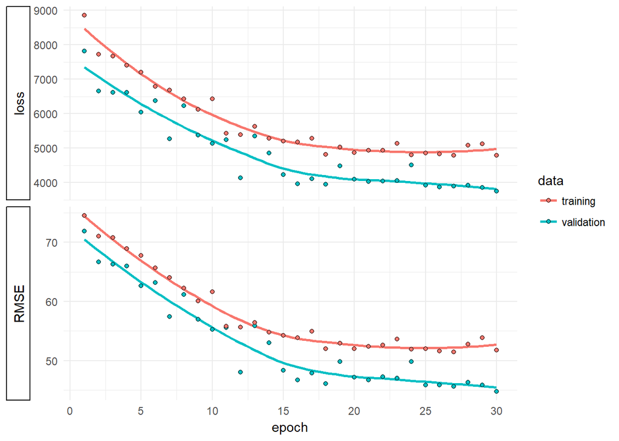

```r
X <- model.matrix(~ min_crse_num + max_crse_num + avg_crse_num + numCourses + missing_fos - 1, data = raw_lookups)
y <- raw_lookups$missing_crse

X_train <- X[raw_lookups$train_id == "train",]
y_train <- y[raw_lookups$train_id == "train"]
X_valid <- X[raw_lookups$train_id == "valid",]
y_valid <- y[raw_lookups$train_id == "valid"]

dropoutRate <- .50
inputShape <- dim(X)[-1]
numUnits <- 2048
numHiddenLayers <- 2

# Custom RMSE Metric since Keras only has MSE
metric_root_mean_squared_error <- function(y_true, y_pred) {
  sqrt(metric_mean_squared_error(y_true, y_pred))
}

model <- keras_model_sequential()
model %>%
    layer_dense(units = numUnits, kernel_initializer = "glorot_normal",
              input_shape = inputShape) %>%
    layer_activation(activation = "relu") %>%
    layer_dropout(rate = dropoutRate)

    for(i in seq(1, numHiddenLayers)){
        model %>%
            layer_dense(units = numUnits, kernel_initializer = "glorot_normal") %>%
            layer_activation(activation = "relu") %>%
            layer_dropout(rate = dropoutRate)
    }

    model %>%
        layer_dense(units = 1) %>%
        layer_activation(activation = "linear")

model %>% compile(loss = 'mean_squared_error',
                  optimizer = optimizer_adam(),
                  metrics =  c(RMSE = metric_root_mean_squared_error))

history <- model %>%
  fit(X_train, y_train, epochs = 30,
      validation_data = list(X_valid, y_valid), batch_size = 128)

plot(history)
```

```r
raw_lookups$crse_pred_nn <- predict(model, X)
sqrt(tapply((raw_lookups$missing_crse - raw_lookups$crse_pred_nn)^2, raw_lookups$train_id, mean))
```

[output not shown]

# Summary and Conclusions

In conclusion, after reading in 8868 lookups that I collected, processing them, and removing courses to predict, I created over 7 models for predicting the field of study and course number. The final models chosen were a dense neural network and a gradient boosted tree model for field of study and course number respectively. These final models produce the following accuracy and RMSE.

|  | Field of Study | Field of Study - Top 5 | Course Number |
| --- | --- | --- | --- |
| Validation Accuracy | 40.44% | 70.2% |  |
| Validation RMSE |  |  | 51.36 |

Some things I would try differently next time is experimenting with the data splitting to put individuals into training or validation, rather than randomly splitting. Another thing that would greatly help is having much more data to work with since I only had 8868 datapoints to work with. Overall, I am quite pleased with the results I have achieved; I believe that if I could somehow implement this recommendation feature on my schedule generator it would be helpful to students.